# Analiza generacijske obnove u Srbiji

U nastavku su prikazani rezultati ukrštanja odabranih varijabli iz Ankete o strukturi poljoprivrednih gazdinstava iz 2018. godine (FSS 2018) sa odgovarajućim socio-ekonomskim varijablama na nivou opština. Cilj je da se kvantifikovuje i opiše dinamika generacijske obnove u poljoprivredi Srbije.  
S ozbzirom da je reč o podacima koji su dostupni u mašinski čitljivom formatu, sužen je obuhvat dostupnih varijabli na one koje su otpremljene u OpenData portalu RS.

*FSS 2018 varijable*  
- nosioci po starosnim grupama  
- intervali KPZ u ha.

*Varijable na opštinskom nivou*  
- stepen razvijenosti JLSU prema Uredbi o utvrđivanju jedinstvene liste razvijenosti regiona i jedinica LSU iz 2014. godine.

# Nosioci poljoprivrednih gazdinstava prema starosnim kohortima u Republici Srbiji

*Izvor podataka*: Portal otvorenih podataka RZS. Podaci preuzeti u mašinski čitljivom formatu, sa linka https://opendata.stat.gov.rs/odata/?id=sr-lat.

## *Priprema podataka za analizu (sređivanje podataka) - Data Preparation*

Dodavanje biblioteka za rad

```r
library(knitr)
library(kableExtra)
library(dplyr)
library(forcats)
library(tidyr)
library(ggplot2)
```

Učitavanje podataka/csv fajla

```r
kbl(yfp[1:5, ], caption = "Tabela sa ulaznim podacima") %>%
  kable_paper("hover", full_width = F) # Pregled tabele - prvih pet redova
```

Tabela sa ulaznim podacima

| IDTer | nTer | idnstj2 | nREG | IDIntervalKPZ | nIntervalKPZ | IDStarInt | nStarInt | brojG | razvoj |
| --- | --- | --- | --- | --- | --- | --- | --- | --- | --- |
| 70017 | Aleksandrovac | RS21 | Region Sumadije i Zapadne Srbije | 7 | Ukupno | 6 | Ukupno | 4987 | II grupa |
| 70017 | Aleksandrovac | RS21 | Region Sumadije i Zapadne Srbije | 1 | < 1 ha | 6 | Ukupno | 417 | II grupa |
| 70017 | Aleksandrovac | RS21 | Region Sumadije i Zapadne Srbije | 1 | < 1 ha | 6 | Ukupno | 760 | II grupa |
| 70017 | Aleksandrovac | RS21 | Region Sumadije i Zapadne Srbije | 2 | 1<=ha<2 | 6 | Ukupno | 1320 | II grupa |
| 70017 | Aleksandrovac | RS21 | Region Sumadije i Zapadne Srbije | 3 | 2<=ha<5 | 6 | Ukupno | 2014 | II grupa |

Pregled tipa podataka i pretvaranje character varijabli “IDIntervalKPZ” i “razvoj” u uređene faktor varijable

```r
sapply(yfp, class) # Pregled tipa podataka
```

```
##         IDTer          nTer       idnstj2          nREG IDIntervalKPZ
##     "integer"   "character"   "character"   "character"     "integer"
##  nIntervalKPZ     IDStarInt      nStarInt         brojG        razvoj
##   "character"     "integer"   "character"     "integer"   "character"
```

```r
names <- c('nIntervalKPZ' ,'razvoj')
yfp[,names] <- lapply(yfp[,names] , factor)
str(yfp)
```

```
## 'data.frame':    11704 obs. of  10 variables:
##  $ IDTer        : int  70017 70017 70017 70017 70017 70017 70017 70017 70017 70017 ...
##  $ nTer         : chr  "Aleksandrovac" "Aleksandrovac" "Aleksandrovac" "Aleksandrovac" ...
##  $ idnstj2      : chr  "RS21" "RS21" "RS21" "RS21" ...
##  $ nREG         : chr  "Region Sumadije i Zapadne Srbije" "Region Sumadije i Zapadne Srbije" "Region Sumadije i Zapadne Srbije" "Region Sumadije i Zapadne Srbije" ...
##  $ IDIntervalKPZ: int  7 1 1 2 3 4 5 5 5 6 ...
##  $ nIntervalKPZ : Factor w/ 7 levels "< 1 ha","1<=ha<2",..: 7 1 1 2 4 5 3 3 3 6 ...
##  $ IDStarInt    : int  6 6 6 6 6 6 6 6 6 6 ...
##  $ nStarInt     : chr  "Ukupno" "Ukupno" "Ukupno" "Ukupno" ...
##  $ brojG        : int  4987 417 760 1320 2014 417 49 10 0 0 ...
##  $ razvoj       : Factor w/ 5 levels "I grupa","II grupa",..: 2 2 2 2 2 2 2 2 2 2 ...
```

Određivanje redosleda nivoa faktora

```r
yfp <- yfp %>%
  mutate(nIntervalKPZ = fct_relevel(nIntervalKPZ, "ha>=50", "10<=ha<50", "5<=ha<10", "2<=ha<5", "1<=ha<2", "< 1 ha"))
```

Kreiranje novog objekta sa filtriranim podacima prema kriterijumu starosti

Izdvojeni podaci za nosioce starosti do 35 godina i 65 i više godina. Nije moguće izdvojiti nosioce starosti do 40 godina s obzirom da su na Open Data portalu objavljeni podaci za intervale do 25,25-35,35-45,45-55,55-65, preko 65 godina.

```r
kohort <- c("Ukupno", "do35", "god>=65")
yfp_kohort <- yfp %>%
  filter(nStarInt %in% kohort) %>%
  select(starts_with("n"), c("brojG", "razvoj"))
```

Grupisanje podataka po kolonama na osnovu kriterijuma u redu

```r
yfp_kohort1 <- yfp_kohort %>%
  group_by(nTer, nREG, nIntervalKPZ, nStarInt, razvoj) %>%
    summarise_all(~ if(is.numeric(.)) sum(., na.rm = TRUE)) # grupisanje na osnovu odabranih varijabli
```

Transformisanje iz long formata u wide format tabele

```r
yfp_kohort1 <- yfp_kohort1 %>%
  spread(key = nStarInt, value = brojG)
```

## *Elemenetarna deskriptivna statistička analiza - Data Analysis*

Kreiranje novih varijabli - udeli odabranih starosnih grupa u ukupnom broju nosilaca

```r
yfp_kohort2 <- yfp_kohort1 %>%
  mutate(nosioci35.udeo=do35/Ukupno*100,
         nosioci65.udeo=`god>=65`/Ukupno*100) %>%  #sa dodavanjem novih kolona
  replace(is.na(.), 0) %>%
  ungroup %>%
  as.data.frame()
```

Naknadno izracunavanje proseka po regionima (opciono za vizuelizaciju - ne mora)

```r
yfp_kohort2 <- yfp_kohort2 %>%
  group_by(nREG) %>%
  mutate(avg.35=mean(nosioci35.udeo),
        avg.65=mean(nosioci65.udeo)) %>%
  ungroup %>%
  as.data.frame()
```

Prikazivanje numerickih vrednosti u odabranim kolonama sa dva decimalna mesta

```r
yfp_df <- yfp_kohort2 %>%
  mutate_at(8:11,
            round,
            digits = 2)%>%
  ungroup %>%
  as.data.frame()
```

## *Vizuelizacija podataka o nosiocima poljoprivrednih gazdinstava - Data Visualisation*

Crtanje grafikona uz pomoc biblioteke “ggplot”.  
*Jednodimenzionalni aspekt*

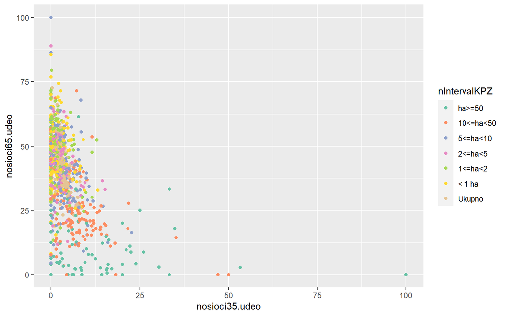

```r
ggplot(data = yfp_df,
       aes(x = nosioci35.udeo, y = nosioci65.udeo, color = nIntervalKPZ)) +
       geom_point() +
       scale_color_brewer(type = "qual", palette = "Set2")
```

*Dvodimenzionalni aspekt*

```r
gg <- ggplot(data = yfp_df, aes(x = nosioci35.udeo, y = nosioci65.udeo, color = nIntervalKPZ)) +
  geom_point(size = 1.2, alpha = 0.60) +
  facet_grid(razvoj~nREG) +
  scale_y_continuous(limits = c(0, 80)) +
  scale_x_continuous(limits = c(0, 60), expand = c(0.005, 0.000)) +
  scale_color_brewer(type = "qual", palette = 2)
```

```r
set.seed(123)
```

```r
ggYfp <- gg +
  geom_jitter(size = 2, alpha = 0.25, width = 0.1) +
  geom_point(aes(avg.35, avg.65),
             size = 4.5,
             color = "#3a4f46") +
  guides(color = guide_legend(override.aes = list(size = 2))) +
  theme(legend.text = element_text(size = 8)) +
  annotate("text", x = 40, y = 70, # gornji desni ugao polja
           size = 2.3,
           label = "Prosek.RS, %: 3,1 (nosioci <35) \n 42,8 (nosioci 65+)",
           colour = "gray10")
```

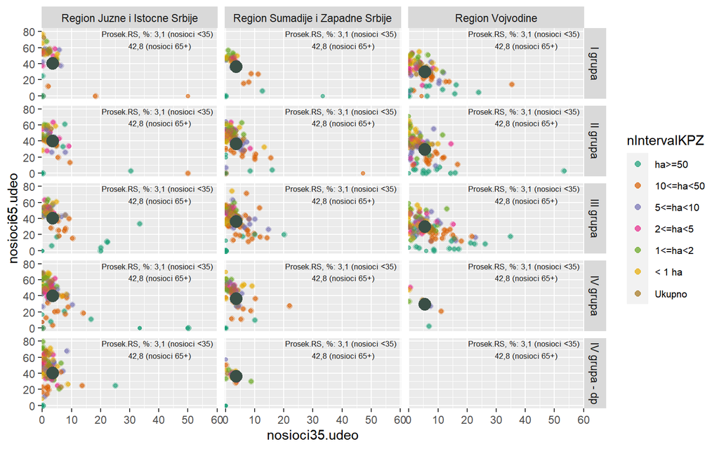

```r
print(ggYfp) # prikaz objekta
```

Izvoz grafikona

```r
ggsave("yfp_graf.tiff", ggYfp, width=30, height=20, units="cm", dpi=280) # snimanje grafikona kao slike
```

© 2022 Milena B. Stevović. All rights reserved.